# Handling Large Datasets in R

Somnath Chaudhuri, University of Southampton, UK

February 08, 2026

# Introduction to Handling Large Datasets

Welcome to our **Big Data Analysis and Management** training! In this section, you’ll learn practical techniques for handling large datasets efficiently in R. Each step includes **what you’ll learn**, **why it matters**, and **how to run** the examples.

## Learning Objectives

By the end of this section, you will be able to:

1. Understand memory constraints when working with large datasets
2. Use **data.table** for fast data manipulation
3. Apply memory‑efficient techniques with **dplyr**
4. Implement chunk processing for very large files
5. Work with real‑world **health** and **environmental** datasets

## Required Packages

**Install (run once):**

```r
install.packages(c("data.table", "dplyr", "ggplot2", "DT",
                   "kableExtra", "microbenchmark", "pryr", "readr", "tibble"))
```

**Load and set display options:**

```r
library(data.table)
library(dplyr)
library(ggplot2)
library(DT)
library(kableExtra)
library(microbenchmark)
library(pryr)
library(readr)
library(tibble)

options(dplyr.print_max = 20,
        dplyr.print_min = 5,
        digits = 4,
        scipen = 999)
```

# 1. Understanding Memory Constraints

## 1.1 Checking Available Memory

**What you’ll learn**: How to assess available memory before loading or transforming large files.  
**Why it matters**: Many operations may need **2–3×** the data size (sorting, joins, copies).  
**How to run**: Execute the chunk; results are shown as a small table/list.

```r
get_memory_status <- function() {
  if (.Platform$OS.type == "windows") {
    total_memory <- tryCatch(memory.limit(), error = function(e) NA)
    used_memory  <- tryCatch(memory.size(),  error = function(e) NA)
    tibble(
      Metric = c("Total memory (MB)", "Used memory (MB)", "Percent used (%)"),
      Value  = c(total_memory,
                 used_memory,
                 ifelse(is.na(total_memory) | is.na(used_memory), NA, round(used_memory/total_memory*100, 1)))
    )
  } else {
    # Cross‑platform approximate snapshot using pryr
    tibble(
      Metric = c("Approx memory in use (MB)"),
      Value  = round(as.numeric(mem_used())/1024^2, 2)
    )
  }
}

mem_snapshot <- get_memory_status()
knitr::kable(mem_snapshot, caption = "Memory status snapshot")
```

Memory status snapshot

| Metric | Value |
| --- | --- |
| Total memory (MB) | Inf |
| Used memory (MB) | Inf |
| Percent used (%) | NaN |

## 1.2 Creating Test Directory Structure

**What you’ll learn**: Set up a simple, reusable project structure.  
**Why it matters**: Keeps data, outputs, and figures organized for reproducibility.

```r
create_directories <- function() {
  dirs <- c("data", "output", "figures", "temp")
  status <- sapply(dirs, function(dir){ if(!dir.exists(dir)) {dir.create(dir); "created"} else {"exists"} })
  tibble(Directory = dirs, Status = unname(status))
}

 dir_status <- create_directories()
knitr::kable(dir_status, caption = "Project directories and status")
```

Project directories and status

| Directory | Status |
| --- | --- |
| data | exists |
| output | exists |
| figures | exists |
| temp | exists |

# 2. Downloading Sample Datasets

We’ll work with two public datasets: (1) **COVID‑19 global data** and (2) **Air pollution by city**.  
> *Tip:* Downloads can be large—ensure you have a stable connection.

## 2.1 Health Dataset: COVID‑19 Global Data

```r
download_covid_data <- function() {
  covid_url  <- "https://raw.githubusercontent.com/owid/covid-19-data/master/public/data/owid-covid-data.csv"
  covid_file <- "data/covid19_global.csv"
  if (!file.exists(covid_file)) {
    start_time <- Sys.time()
    download.file(covid_url, covid_file, mode = "wb", quiet = FALSE)
    end_time <- Sys.time()
    tibble(
      File = basename(covid_file),
      Path = covid_file,
      Download_Time_s = round(as.numeric(end_time - start_time), 2),
      Size_MB = round(file.info(covid_file)$size/1024^2, 2)
    )
  } else {
    tibble(
      File = basename(covid_file),
      Path = covid_file,
      Download_Time_s = 0,
      Size_MB = round(file.info(covid_file)$size/1024^2, 2)
    )
  }
}

covid_meta <- download_covid_data()
knitr::kable(covid_meta, caption = "COVID‑19 dataset download summary")
```

COVID‑19 dataset download summary

| File | Path | Download_Time_s | Size_MB |
| --- | --- | --- | --- |
| covid19_global.csv | data/covid19_global.csv | 0 | 93.83 |

```r
covid_file <- covid_meta$Path[1]
```

## 2.2 Environmental Dataset: Air Pollution Data

```r
download_air_pollution_data <- function() {
  air_url  <- "https://raw.githubusercontent.com/owid/owid-datasets/master/datasets/Air%20pollution%20by%20city%20-%20Fouquet%20and%20DPCC%20(2011)/Air%20pollution%20by%20city%20-%20Fouquet%20and%20DPCC%20(2011).csv"
  air_file <- "data/air_pollution.csv"
  if (!file.exists(air_file)) {
    start_time <- Sys.time()
    download.file(air_url, air_file, mode = "wb", quiet = FALSE)
    end_time <- Sys.time()
    tibble(
      File = basename(air_file), Path = air_file,
      Download_Time_s = round(as.numeric(end_time - start_time), 2),
      Size_MB = round(file.info(air_file)$size/1024^2, 2)
    )
  } else {
    tibble(
      File = basename(air_file), Path = air_file,
      Download_Time_s = 0,
      Size_MB = round(file.info(air_file)$size/1024^2, 2)
    )
  }
}

air_meta <- download_air_pollution_data()
knitr::kable(air_meta, caption = "Air pollution dataset download summary")
```

Air pollution dataset download summary

| File | Path | Download_Time_s | Size_MB |
| --- | --- | --- | --- |
| air_pollution.csv | data/air_pollution.csv | 0 | 0.01 |

```r
air_file <- air_meta$Path[1]
```

# 3. Exploring Dataset Structure

## 3.1 Quick File Inspection

**What you’ll learn**: Inspect file size, column names, and row count **without** loading the full file.  
**Why it matters**: Helps estimate memory needed and plan chunked workflows.

```r
inspect_dataset <- function(file_path) {
  file_size_mb <- round(file.info(file_path)$size/1024^2, 2)
  sample_dt    <- data.table::fread(file_path, nrows = 100)
  n_cols       <- ncol(sample_dt)
  # Try fast row count via system tools; fallback to NA if unavailable
  row_count <- tryCatch({
    as.numeric(system2("wc", args = c("-l", file_path), stdout = TRUE)) - 1
  }, error = function(e) NA)
  tibble(
    File = basename(file_path),
    Size_MB = file_size_mb,
    Estimated_Rows = row_count,
    N_Columns = n_cols,
    Columns_Preview = paste(names(sample_dt), collapse = ", ")
  )
}

covid_info <- inspect_dataset(covid_file)
air_info   <- inspect_dataset(air_file)

knitr::kable(covid_info, caption = "COVID‑19 file inspection")
```

COVID‑19 file inspection

| File | Size_MB | Estimated_Rows | N_Columns | Columns_Preview |
| --- | --- | --- | --- | --- |
| covid19_global.csv | 93.83 | NA | 67 | iso_code, continent, location, date, total_cases, new_cases, new_cases_smoothed, total_deaths, new_deaths, new_deaths_smoothed, total_cases_per_million, new_cases_per_million, new_cases_smoothed_per_m… |

```r
knitr::kable(air_info,   caption = "Air pollution file inspection")
```

Air pollution file inspection

| File | Size_MB | Estimated_Rows | N_Columns | Columns_Preview |
| --- | --- | --- | --- | --- |
| air_pollution.csv | 0.01 | NA | 4 | Entity, Year, Smoke (Fouquet and DPCC (2011)), Suspended Particulate Matter (SPM) (Fouquet and DPCC (2011)) |

## 3.2 Display Sample Data

**How to run**: The previews below use **DT** for scrolling and search.

```r
DT::datatable(data.table::fread(covid_file, nrows = 10),
              options = list(pageLength = 10, scrollX = TRUE),
              caption = "COVID‑19 Data Sample (First 10 rows)")
```

|  | iso_code | continent | location | date | total_cases | new_cases | new_cases_smoothed | total_deaths | new_deaths | new_deaths_smoothed | total_cases_per_million | new_cases_per_million | new_cases_smoothed_per_million | total_deaths_per_million | new_deaths_per_million | new_deaths_smoothed_per_million | reproduction_rate | icu_patients | icu_patients_per_million | hosp_patients | hosp_patients_per_million | weekly_icu_admissions | weekly_icu_admissions_per_million | weekly_hosp_admissions | weekly_hosp_admissions_per_million | total_tests | new_tests | total_tests_per_thousand | new_tests_per_thousand | … |
| --- | --- | --- | --- | --- | --- | --- | --- | --- | --- | --- | --- | --- | --- | --- | --- | --- | --- | --- | --- | --- | --- | --- | --- | --- | --- | --- | --- | --- | --- | --- |
| 1 | AFG | Asia | Afghanistan | 2020-01-05 | 0 | 0 |  | 0 | 0 |  | 0 | 0 |  | 0 | 0 |  |  |  |  |  |  |  |  |  |  |  |  |  |  | … |
| 2 | AFG | Asia | Afghanistan | 2020-01-06 | 0 | 0 |  | 0 | 0 |  | 0 | 0 |  | 0 | 0 |  |  |  |  |  |  |  |  |  |  |  |  |  |  | … |
| 3 | AFG | Asia | Afghanistan | 2020-01-07 | 0 | 0 |  | 0 | 0 |  | 0 | 0 |  | 0 | 0 |  |  |  |  |  |  |  |  |  |  |  |  |  |  | … |
| 4 | AFG | Asia | Afghanistan | 2020-01-08 | 0 | 0 |  | 0 | 0 |  | 0 | 0 |  | 0 | 0 |  |  |  |  |  |  |  |  |  |  |  |  |  |  | … |
| 5 | AFG | Asia | Afghanistan | 2020-01-09 | 0 | 0 |  | 0 | 0 |  | 0 | 0 |  | 0 | 0 |  |  |  |  |  |  |  |  |  |  |  |  |  |  | … |
| 6 | AFG | Asia | Afghanistan | 2020-01-10 | 0 | 0 | 0 | 0 | 0 | 0 | 0 | 0 | 0 | 0 | 0 | 0 |  |  |  |  |  |  |  |  |  |  |  |  |  | … |
| 7 | AFG | Asia | Afghanistan | 2020-01-11 | 0 | 0 | 0 | 0 | 0 | 0 | 0 | 0 | 0 | 0 | 0 | 0 |  |  |  |  |  |  |  |  |  |  |  |  |  | … |
| 8 | AFG | Asia | Afghanistan | 2020-01-12 | 0 | 0 | 0 | 0 | 0 | 0 | 0 | 0 | 0 | 0 | 0 | 0 |  |  |  |  |  |  |  |  |  |  |  |  |  | … |
| 9 | AFG | Asia | Afghanistan | 2020-01-13 | 0 | 0 | 0 | 0 | 0 | 0 | 0 | 0 | 0 | 0 | 0 | 0 |  |  |  |  |  |  |  |  |  |  |  |  |  | … |
| 10 | AFG | Asia | Afghanistan | 2020-01-14 | 0 | 0 | 0 | 0 | 0 | 0 | 0 | 0 | 0 | 0 | 0 | 0 |  |  |  |  |  |  |  |  |  |  |  |  |  | … |

```r
DT::datatable(data.table::fread(air_file, nrows = 10),
              options = list(pageLength = 10, scrollX = TRUE),
              caption = "Air Pollution Data Sample (First 10 rows)")
```

|  | Entity | Year | Smoke (Fouquet and DPCC (2011)) | Suspended Particulate Matter (SPM) (Fouquet and DPCC (2011)) |
| --- | --- | --- | --- | --- |
| 1 | Delhi | 1997 |  | 363 |
| 2 | Delhi | 1998 |  | 378 |
| 3 | Delhi | 1999 |  | 375 |
| 4 | Delhi | 2000 |  | 431 |
| 5 | Delhi | 2001 |  | 382 |
| 6 | Delhi | 2002 |  | 456 |
| 7 | Delhi | 2003 |  | 391 |
| 8 | Delhi | 2004 |  | 390 |
| 9 | Delhi | 2005 |  | 373 |
| 10 | Delhi | 2006 |  | 433 |

# 4. Working with data.table

## 4.1 Introduction to data.table

**data.table** is an enhanced `data.frame` with concise syntax and in‑place modifications—ideal for large datasets.

```r
# Fast read with fread()
covid_dt <- fread(covid_file)
summary_tbl <- tibble(Rows = nrow(covid_dt), Columns = ncol(covid_dt))
knitr::kable(summary_tbl, caption = "COVID‑19 data loaded with data.table::fread()")
```

COVID‑19 data loaded with data.table::fread()

| Rows | Columns |
| --- | --- |
| 429435 | 67 |

```r
# Syntax refresher: DT[i, j, by]
syntax_notes <- tibble(
  Component = c("i", "j", "by"),
  Meaning   = c("Row filter (subsetting)", "Columns/expressions (select/compute)", "Grouping variable(s)")
)
knitr::kable(syntax_notes, caption = "Core data.table indexing components")
```

Core data.table indexing components

| Component | Meaning |
| --- | --- |
| i | Row filter (subsetting) |
| j | Columns/expressions (select/compute) |
| by | Grouping variable(s) |

## 4.2 Filtering and Selecting Data

```r
# Example 1: Country filter (United States)
us_data <- covid_dt[location == "United States", ]
knitr::kable(head(us_data, 5), caption = sprintf("United States rows (showing 5 of %s)", format(nrow(us_data), big.mark=",")))
```

United States rows (showing 5 of 1,674)

| iso_code | continent | location | date | total_cases | new_cases | new_cases_smoothed | total_deaths | new_deaths | new_deaths_smoothed | total_cases_per_million | new_cases_per_million | new_cases_smoothed_per_million | total_deaths_per_million | new_deaths_per_million | new_deaths_smoothed_per_million | reproduction_rate | icu_patients | icu_patients_per_million | hosp_patients | hosp_patients_per_million | weekly_icu_admissions | weekly_icu_admissions_per_million | weekly_hosp_admissions | weekly_hosp_admissions_per_million | total_tests | new_tests | total_tests_per_thousand | new_tests_per_thousand | new_tests_smoothed | … |
| --- | --- | --- | --- | --- | --- | --- | --- | --- | --- | --- | --- | --- | --- | --- | --- | --- | --- | --- | --- | --- | --- | --- | --- | --- | --- | --- | --- | --- | --- | --- |
| USA | North America | United States | 2020-01-05 | 0 | 0 | NA | 0 | 0 | NA | 0 | 0 | NA | 0 | 0 | NA | NA | NA | NA | NA | NA | NA | NA | NA | NA | NA | NA | NA | NA | NA | … |
| USA | North America | United States | 2020-01-06 | 0 | 0 | NA | 0 | 0 | NA | 0 | 0 | NA | 0 | 0 | NA | NA | NA | NA | NA | NA | NA | NA | NA | NA | NA | NA | NA | NA | NA | … |
| USA | North America | United States | 2020-01-07 | 0 | 0 | NA | 0 | 0 | NA | 0 | 0 | NA | 0 | 0 | NA | NA | NA | NA | NA | NA | NA | NA | NA | NA | NA | NA | NA | NA | NA | … |
| USA | North America | United States | 2020-01-08 | 0 | 0 | NA | 0 | 0 | NA | 0 | 0 | NA | 0 | 0 | NA | NA | NA | NA | NA | NA | NA | NA | NA | NA | NA | NA | NA | NA | NA | … |
| USA | North America | United States | 2020-01-09 | 0 | 0 | NA | 0 | 0 | NA | 0 | 0 | NA | 0 | 0 | NA | NA | NA | NA | NA | NA | NA | NA | NA | NA | NA | NA | NA | NA | NA | … |

```r
# Example 2: Select specific columns
selected_cols <- covid_dt[, .(date, location, total_cases, total_deaths, population)]
knitr::kable(head(selected_cols, 5), caption = "Selected columns preview")
```

Selected columns preview

| date | location | total_cases | total_deaths | population |
| --- | --- | --- | --- | --- |
| 2020-01-05 | Afghanistan | 0 | 0 | 41128772 |
| 2020-01-06 | Afghanistan | 0 | 0 | 41128772 |
| 2020-01-07 | Afghanistan | 0 | 0 | 41128772 |
| 2020-01-08 | Afghanistan | 0 | 0 | 41128772 |
| 2020-01-09 | Afghanistan | 0 | 0 | 41128772 |

```r
# Example 3: Filter + select + sort
recent_us_data <- covid_dt[
  location == "United States" & total_cases > 1000000,
  .(date, total_cases, total_deaths, new_cases)
][order(-total_cases)]
knitr::kable(head(recent_us_data, 5), caption = sprintf("US rows with >1M cases (n = %s) — top 5", format(nrow(recent_us_data), big.mark=",")))
```

US rows with >1M cases (n = 1,555) — top 5

| date | total_cases | total_deaths | new_cases |
| --- | --- | --- | --- |
| 2023-05-14 | 103436829 | 1127152 | 93260 |
| 2023-05-15 | 103436829 | 1127152 | 0 |
| 2023-05-16 | 103436829 | 1127152 | 0 |
| 2023-05-17 | 103436829 | 1127152 | 0 |
| 2023-05-18 | 103436829 | 1127152 | 0 |

## 4.3 Aggregation Operations

```r
# Example 1: Total cases by country (max across time)
total_by_country <- covid_dt[
  !is.na(total_cases),
  .(total_cases_max  = max(total_cases,  na.rm = TRUE),
    total_deaths_max = max(total_deaths, na.rm = TRUE),
    avg_new_cases    = mean(new_cases,   na.rm = TRUE)),
  by = .(location, continent)
][order(-total_cases_max)]

knitr::kable(head(total_by_country, 5), caption = "Top 5 countries by total cases (max)")
```

| location | continent | total_cases_max | total_deaths_max | avg_new_cases |
| --- | --- | --- | --- | --- |
| World |  | 775866783 | 7057132 | 463522 |
| High-income countries |  | 429044049 | 2997359 | 256299 |
| Asia |  | 301499099 | 1637249 | 180146 |
| Europe |  | 252916868 | 2102483 | 151085 |
| Upper-middle-income countries |  | 251753518 | 2824452 | 150392 |

```r
# Example 2: Summary statistics by continent
summary_stats <- covid_dt[
  !is.na(new_cases),
  .(mean_cases = mean(new_cases,   na.rm = TRUE),
    median_cases = median(new_cases, na.rm = TRUE),
    sd_cases = sd(new_cases,         na.rm = TRUE),
    min_cases = min(new_cases,       na.rm = TRUE),
    max_cases = max(new_cases,       na.rm = TRUE),
    total_observations = .N),
  by = continent
]

knitr::kable(summary_stats, caption = "New case statistics by continent")
```

New case statistics by continent

| continent | mean_cases | median_cases | sd_cases | min_cases | max_cases | total_observations |
| --- | --- | --- | --- | --- | --- | --- |
| Asia | 3833.0 | 0 | 181035 | 0 | 40475477 | 78675 |
|  | 125072.5 | 0 | 958888 | 0 | 44236227 | 20088 |
| Europe | 3004.1 | 0 | 35560 | 0 | 2417043 | 84190 |
| Africa | 137.8 | 0 | 2033 | 0 | 162987 | 95411 |
| Oceania | 373.5 | 0 | 8810 | 0 | 588813 | 40172 |
| North America | 1825.7 | 0 | 49486 | 0 | 5650933 | 68188 |
| South America | 2936.2 | 0 | 28666 | 0 | 1283024 | 23435 |

## 4.4 Memory‑Efficient Operations

```r
# Measure memory before and after a light operation
mem_before <- mem_used()
efficient_select <- covid_dt[, .SD, .SDcols = c("date", "location", "total_cases")]
mem_after  <- mem_used()

mem_comp <- tibble(
  Stage = c("Before", "After selection", "Difference (MB)"),
  MB    = c(round(as.numeric(mem_before)/1024^2,2),
            round(as.numeric(mem_after)/1024^2,2),
            round(as.numeric(mem_after - mem_before)/1024^2,2))
)
knitr::kable(mem_comp, caption = "Approximate memory usage during column selection")
```

Approximate memory usage during column selection

| Stage | MB |
| --- | --- |
| Before | 302.68 |
| After selection | 310.87 |
| Difference (MB) | 8.18 |

```r
# Clean up
rm(efficient_select); gc()
```

```
##            used  (Mb) gc trigger  (Mb) max used  (Mb)
## Ncells  1302858  69.6    2538141 135.6  2538141 135.6
## Vcells 30548170 233.1   63050654 481.1 63008167 480.8
```

# 5. Working with dplyr Efficiently

## 5.1 Reading Large Files with readr

**Hint**: `readr::read_csv()` is fast and type‑aware; great when you want tidyverse compatibility.

```r
# Example: read selected columns and parse types
covid_df <- read_csv(covid_file,
                     col_types = cols(
                       date         = col_date(),
                       total_cases  = col_double(),
                       total_deaths = col_double(),
                       population   = col_double()
                     ),
                     progress = TRUE)
```

[output not shown]

```r
tbl_summary <- tibble(Rows = nrow(covid_df), Columns = ncol(covid_df))
knitr::kable(tbl_summary, caption = "COVID‑19 data loaded with readr::read_csv()")
```

COVID‑19 data loaded with readr::read_csv()

| Rows | Columns |
| --- | --- |
| 429435 | 67 |

## 5.2 dplyr Operations on Large Data

```r
# Example 1: Filter & select (United States)
us_data_dplyr <- covid_df %>%
  filter(location == "United States" & !is.na(total_cases)) %>%
  select(date, total_cases, total_deaths, new_cases, population) %>%
  arrange(desc(total_cases))

knitr::kable(head(us_data_dplyr, 5), caption = sprintf("US data rows (showing 5 of %s)", format(nrow(us_data_dplyr), big.mark=",")))
```

US data rows (showing 5 of 1,674)

| date | total_cases | total_deaths | new_cases | population |
| --- | --- | --- | --- | --- |
| 2023-05-14 | 103436829 | 1127152 | 93260 | 338289856 |
| 2023-05-15 | 103436829 | 1127152 | 0 | 338289856 |
| 2023-05-16 | 103436829 | 1127152 | 0 | 338289856 |
| 2023-05-17 | 103436829 | 1127152 | 0 | 338289856 |
| 2023-05-18 | 103436829 | 1127152 | 0 | 338289856 |

```r
# Example 2: Grouped summaries
authoritative <- covid_df %>%
  group_by(continent, location) %>%
  summarise(
    max_cases    = max(total_cases,  na.rm = TRUE),
    max_deaths   = max(total_deaths, na.rm = TRUE),
    avg_new_cases = mean(new_cases,  na.rm = TRUE),
    .groups = 'drop'
  ) %>%
  arrange(desc(max_cases))

knitr::kable(slice_head(authoritative, n = 5), caption = "Top 5 countries by total cases (dplyr)")
```

| continent | location | max_cases | max_deaths | avg_new_cases |
| --- | --- | --- | --- | --- |
| NA | World | 775866783 | 7057132 | 463522 |
| NA | High-income countries | 429044049 | 2997359 | 256299 |
| NA | Asia | 301499099 | 1637249 | 180146 |
| NA | Europe | 252916868 | 2102483 | 151085 |
| NA | Upper-middle-income countries | 251753518 | 2824452 | 150392 |

## 5.3 Chunk Processing with dplyr (readr)

**Why use chunks?** When files exceed memory, process sequential pieces and combine summaries.  
**How to run**: The chunk below is intensive—uncomment to run interactively.

```r
process_in_chunks <- function(file_path, chunk_size = 100000) {
  callback <- function(x, pos) {
    x %>%
      filter(!is.na(total_cases) & total_cases > 0) %>%
      group_by(location) %>%
      summarise(
        avg_cases = mean(new_cases, na.rm = TRUE),
        max_cases = max(total_cases, na.rm = TRUE),
        rows_processed = n(),
        .groups = 'drop'
      )
  }
  read_csv_chunked(
    file_path,
    callback = DataFrameCallback$new(callback),
    chunk_size = chunk_size,
    col_types = cols(.default = col_character())
  )
}

# chunked_result <- process_in_chunks(covid_file, chunk_size = 50000)
# head(chunked_result)
```

# 6. Performance Comparison

## 6.1 Benchmarking data.table vs dplyr

```r
sample_size <- 100000
sample_dt <- covid_dt[sample(.N, min(sample_size, .N))]
sample_df <- as.data.frame(sample_dt)

# Benchmark 1: Filtering
bm_filter <- microbenchmark(
  data.table = sample_dt[location == "United States" & total_cases > 1000],
  dplyr      = sample_df %>% filter(location == "United States" & total_cases > 1000),
  times = 10
)

# Benchmark 2: Group + summarise
bm_group <- microbenchmark(
  data.table = sample_dt[, .(avg_cases = mean(new_cases, na.rm = TRUE)), by = continent],
  dplyr      = sample_df %>% group_by(continent) %>% summarise(avg_cases = mean(new_cases, na.rm = TRUE), .groups='drop'),
  times = 10
)

bm_filter; bm_group
```

```
## Unit: milliseconds
##        expr   min    lq  mean median    uq   max neval cld
##  data.table 3.045 3.161 3.342  3.252 3.446 3.753    10  a
##       dplyr 7.183 7.833 8.097  8.014 8.535 9.138    10   b
```

```
## Unit: milliseconds
##        expr   min    lq  mean median    uq   max neval cld
##  data.table 5.841 6.690 7.758  7.988 8.780  9.58    10  a
##       dplyr 8.836 9.055 9.572  9.252 9.438 12.18    10   b
```

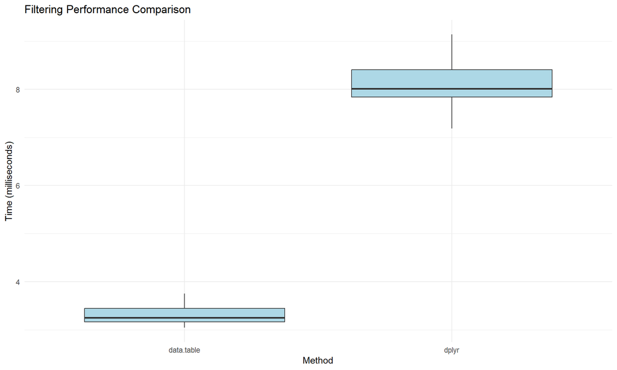

```r
# Visualise filtering results
ggplot(bm_filter, aes(x = expr, y = time/1e6)) +
  geom_boxplot(fill = "lightblue") +
  labs(title = "Filtering Performance Comparison", x = "Method", y = "Time (milliseconds)") +
  theme_minimal()
```

## 6.2 Memory Usage Comparison

```r
compare_memory_usage <- function() {
  # data.table path
  mem_dt_before <- mem_used()
  dt_result <- covid_dt[, .(total = sum(total_cases, na.rm = TRUE)), by = continent]
  mem_dt_after  <- mem_used()
  rm(dt_result); gc()

  # dplyr path
  mem_dplyr_before <- mem_used()
  dplyr_result <- covid_df %>% group_by(continent) %>% summarise(total = sum(total_cases, na.rm = TRUE), .groups='drop')
  mem_dplyr_after  <- mem_used()

  tibble(
    Method = c("data.table", "dplyr"),
    Memory_Used_MB = round(as.numeric(c(mem_dt_after - mem_dt_before, mem_dplyr_after - mem_dplyr_before))/1024^2, 2)
  )
}

memory_comparison <- compare_memory_usage()
knitr::kable(memory_comparison, caption = "Approximate memory used by operation (MB)")
```

Approximate memory used by operation (MB)

| Method | Memory_Used_MB |
| --- | --- |
| data.table | 0.05 |
| dplyr | 0.00 |

# 7. Practical Exercises

## Exercise 1: COVID‑19 Data Analysis

**Task 1.1 — Top 10 countries by total cases**  
*Hint:* Use `max(total_cases)` by `location`.

**Task 1.2 — Case fatality rate (CFR)**  
Compute CFR = `total_deaths / total_cases` by `location`; filter countries with at least 1,000 cases.

**Task 1.3 — Daily growth rate**  
Compute growth rate for `new_cases` using `shift()` (data.table) or `lag()` (dplyr).

## Exercise 2: Air Pollution Analysis

**Dataset load**:

```r
air_data <- fread(air_file)
# Quick info
knitr::kable(tibble(Rows = nrow(air_data), Columns = ncol(air_data)), caption = "Air pollution dataset size")
```

Air pollution dataset size

| Rows | Columns |
| --- | --- |
| 331 | 4 |

**Task 2.1 — City analysis**  
Find cities with highest pollution; group by city and compute relevant averages.

**Task 2.2 — Temporal trends**  
Analyse change over years; create a simple time‑series visualisation.

**Task 2.3 — Regional comparison**  
Compare pollution levels across regions/countries.

# 8. Best Practices and Tips

## 8.1 Memory Management

1. **Use appropriate types**: convert character to factor for repeated categories.
2. **Remove unused columns**: load/select only what you need.
3. **Process in chunks**: for very large files, use `readr::read_csv_chunked()` or databases.
4. **Clear memory regularly**: `rm()` then `gc()`.
5. **Disk‑based structures**: consider `ff`, `bigmemory`, or database backends.

## 8.2 Performance Optimisation

1. **Use data.table for speed**: especially beyond ~1M rows.
2. **Avoid copies**: prefer in‑place updates (`:=` in data.table).
3. **Keys and indexing**: set keys for frequent joins/subsets.
4. **Parallel processing**: use `parallel`, `future`, or `foreach` for CPU‑bound tasks.

## 8.3 Data Storage

1. **Use fst or feather/arrow** for fast read/write.
2. **Databases**: `RSQLite`, `duckdb` for very large/tabular data.
3. **Arrow/Parquet**: efficient columnar storage and out‑of‑memory analytics.
4. **Compression**: `saveRDS(..., compress=TRUE)` to reduce file size.

# 9. Additional Resources

**Documentation**  
- data.table: https://rdatatable.gitlab.io/data.table/  
- dplyr: https://dplyr.tidyverse.org/  
- readr: https://readr.tidyverse.org/

**Books**  
- *R for Data Science* — https://r4ds.had.co.nz/  
- *Efficient R Programming* — https://csgillespie.github.io/efficientR/

**Online Courses**  
- DataCamp: *Working with Large Datasets in R*  
- Coursera: *Big Data Analysis with R and Hadoop*  
- Udemy: *R Programming for Data Science*

# 10. Summary

**Key takeaways**  
✓ **data.table** offers superior speed for large datasets  
✓ **dplyr** provides intuitive syntax and works well with medium datasets  
✓ **Memory management** is crucial when working with large data  
✓ **Chunk processing** enables handling of very large files  
✓ **Choose the right tool** for your use case and **profile** bottlenecks

**Next steps**  
1. Practice with the exercises  
2. Apply these techniques to your own datasets  
3. Explore advanced topics: parallel processing, out‑of‑memory computation  
4. Engage with the R community for support and learning

# Appendix: Complete Code Examples

```r
# Save processed objects
saveRDS(covid_dt, "output/covid_data_processed.rds")
write.csv(us_data_dplyr, "output/us_covid_data.csv", row.names = FALSE)

# Generate a report of memory usage
sink("output/memory_report.txt")
print(get_memory_status())
sink()
```

**This material is part of the training program by The National Centre for Research Methods © [NCRM](https://www.ncrm.ac.uk/about/) authored by [Dr Somnath Chaudhuri](https://www.southampton.ac.uk/people/65ctq8/doctor-somnath-chaudhuri) (University of Southampton). Content is under a CC BY‑style permissive license and can be freely used for educational purposes with proper attribution.**